# FORECAST INPC

Vamos a analizar el INPC (Indice Nacional de Precios al Consumidor). Primero hay que definir que es el índice de precios al consumidor o índice de precios de consumo(comúnmente llamado por su sigla IPC) ; es un índice económico en el que se valoran los precios de un determinado conjunto de bienes y servicios.

Los datos con los que vamos a estar trabajando son mensuales desde el 2018 hasta la actualidad del estado de Jalisco y se le va a dar el tratamiento de Indice, es decir no son miles de pesos , es un conjunto de datos que se proyecta en un dato estadistico.

Primero vamos a observar una grafica de como se comportan los diferentes Objetos de Gasto que se contienen en el INPC, para asi poder pasar a analizarlos cada uno por su parte.

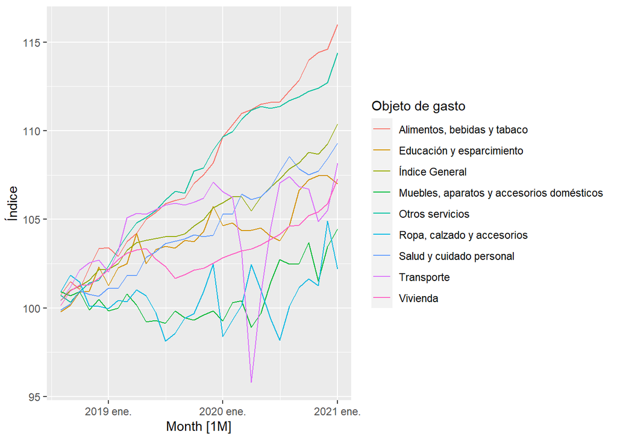

En esta tabla podemos ver cuales son los valores maximos , minimos , promedios y las desviaciones de los diferentes objetos de gasto producidos por el indice del INPC, para hacernos una idea de cuanto son los cambios

|  | Objeto de gasto | mean | min | max | sd |
| --- | --- | --- | --- | --- | --- |
| 1 | Alimentos, bebidas y tabaco | 107.8468 | 100.745 | 115.993 | 4.53468432083813 |
| 2 | Educación y esparcimiento | 103.857133333333 | 99.793 | 107.467 | 2.07898739830208 |
| 3 | Índice General | 105.027366666667 | 100.435 | 110.398 | 2.64806061087177 |
| 4 | Muebles, aparatos y accesorios domésticos | 100.676166666667 | 98.918 | 104.476 | 1.4876643365225 |
| 5 | Otros servicios | 107.488933333333 | 100.326 | 114.386 | 4.26669216084337 |
| 6 | Ropa, calzado y accesorios | 100.5336 | 98.125 | 104.911 | 1.45125941976212 |
| 7 | Salud y cuidado personal | 104.377533333333 | 99.887 | 109.301 | 2.85375924767282 |
| 8 | Transporte | 104.5318 | 95.796 | 108.153 | 2.66751655652038 |
| 9 | Vivienda | 103.092133333333 | 100.151 | 107.296 | 1.56670910825369 |

**INDICE GENERAL**

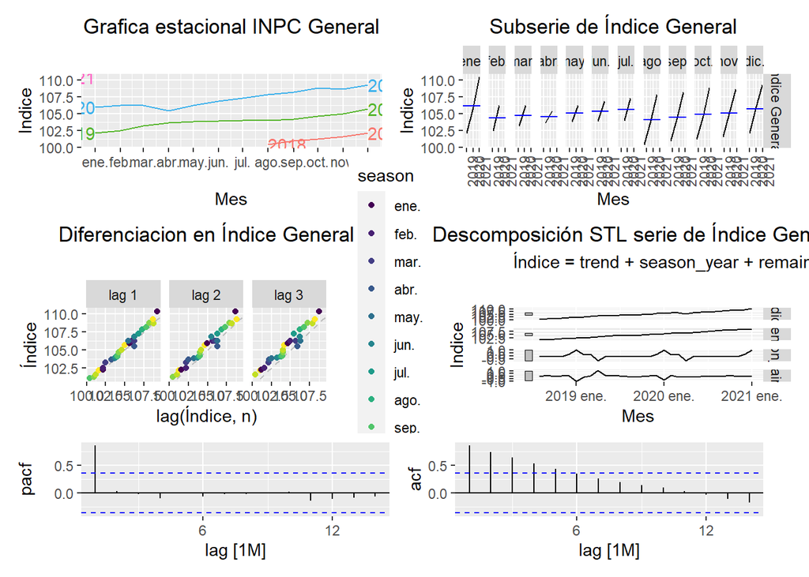

El pronostico para este Índice General es una Arima(0,1,0), asi como sus residuos despues del modelado,asi como un pronostico con el modelos propuesto.

```
## Series: Índice
## Model: ARIMA(0,1,0) w/ drift
##
## Coefficients:
##       constant
##         0.3436
## s.e.    0.0651
##
## sigma^2 estimated as 0.1275:  log likelihood=-10.73
## AIC=25.47   AICc=25.93   BIC=28.2
```

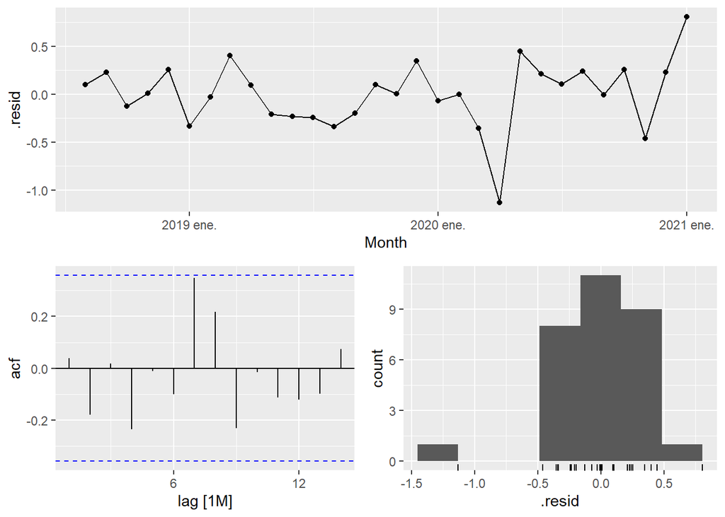

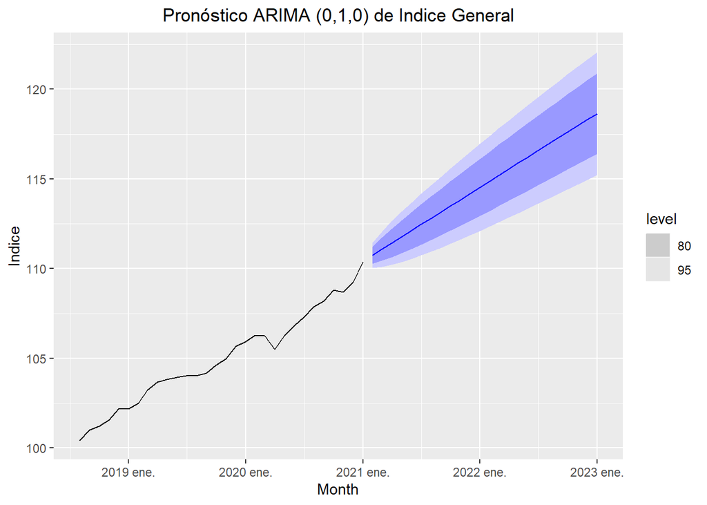

**ALIMENTOS, BEBIDA Y TABACO**

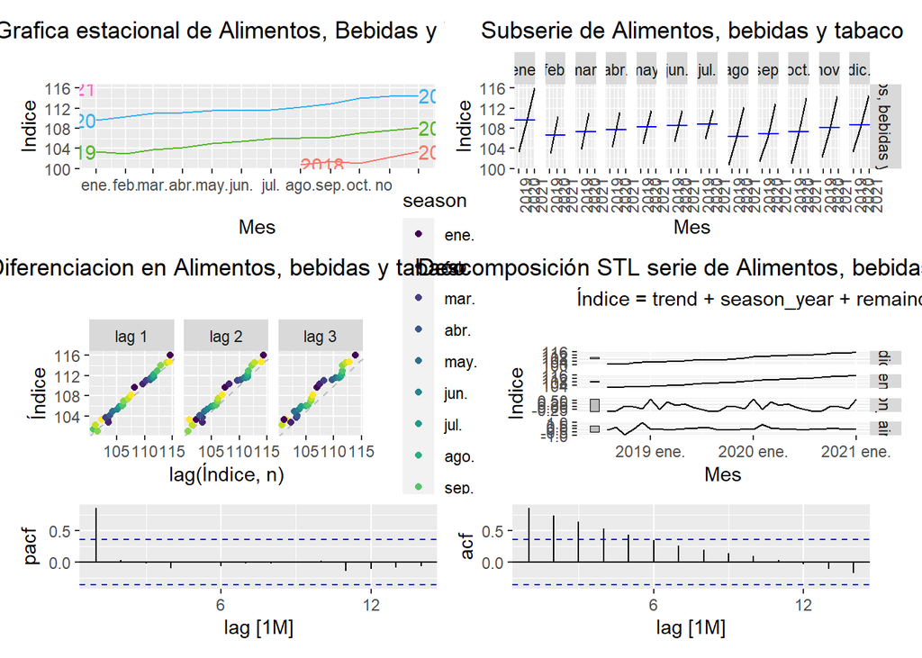

El pronostico para este Alimentos, bebidas y tabaco es una Arima(0,1,0), asi como sus residuos despues del modelado,asi como un pronostico con el modelos propuesto.

```
## Series: Índice
## Model: ARIMA(0,1,0) w/ drift
##
## Coefficients:
##       constant
##         0.5258
## s.e.    0.0875
##
## sigma^2 estimated as 0.2303:  log likelihood=-19.32
## AIC=42.65   AICc=43.11   BIC=45.38
```

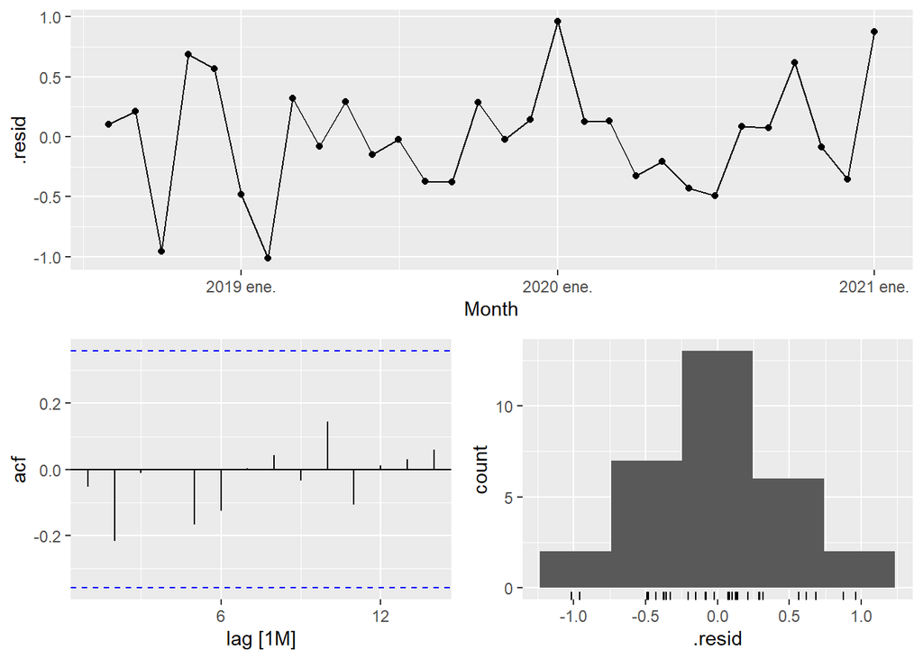

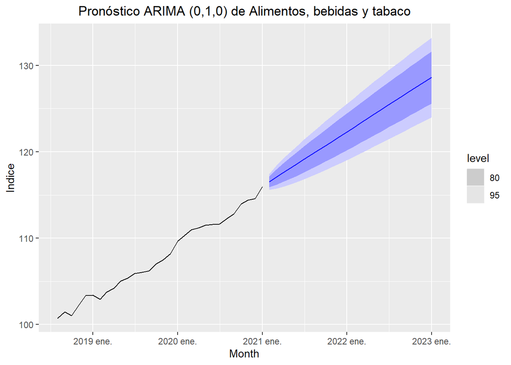

**EDUCACIÓN Y ESPARCIMIENTO**

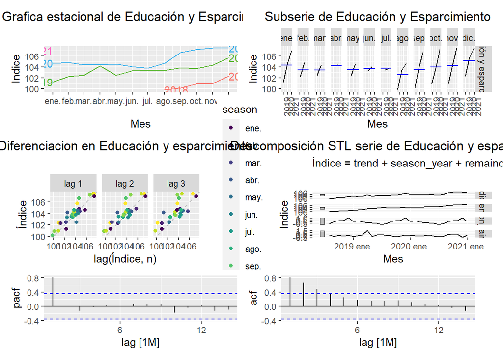

El pronostico para este Educación y Esparcimiento es una Arima(1,1,0), asi como sus residuos despues del modelado,asi como un pronostico con el modelos propuesto.

```
## Series: Índice
## Model: ARIMA(1,1,0) w/ drift
##
## Coefficients:
##           ar1  constant
##       -0.3059    0.3306
## s.e.   0.1754    0.1440
##
## sigma^2 estimated as 0.6352:  log likelihood=-33.57
## AIC=73.15   AICc=74.11   BIC=77.25
```

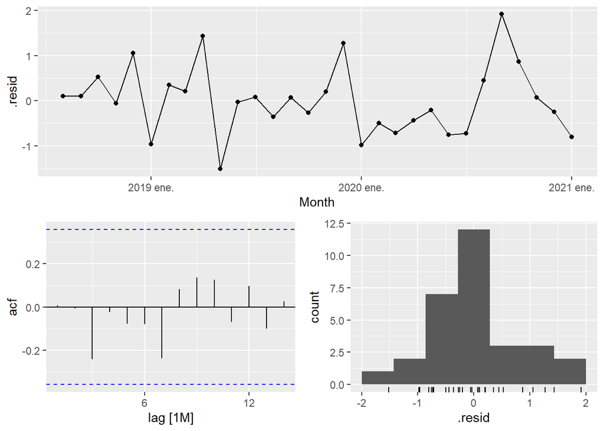

[figure not shown]

**MUEBLES, APARATOS Y ACCESORIOS DOMÉSTICOS**

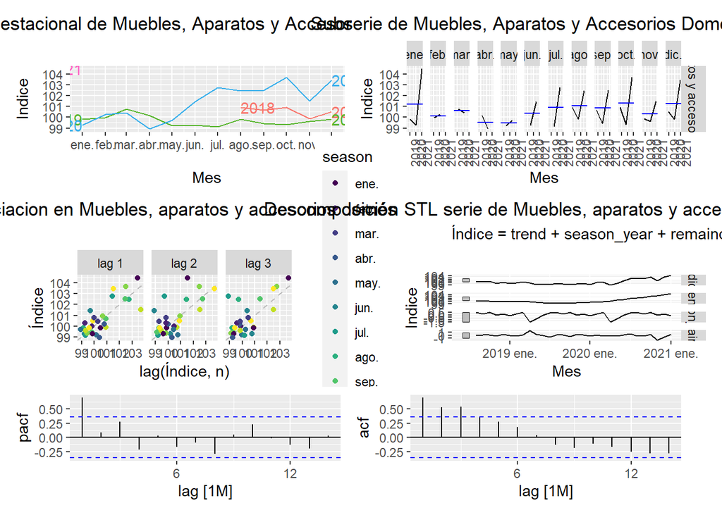

El pronostico para este Muebles, Aparatos y Accesorios Domesticos es una Arima(0,1,0), asi como sus residuos despues del modelado,asi como un pronostico con el modelos propuesto.

```
## Series: Índice
## Model: ARIMA(0,1,0)
##
## sigma^2 estimated as 0.8525:  log likelihood=-38.83
## AIC=79.66   AICc=79.81   BIC=81.02
```

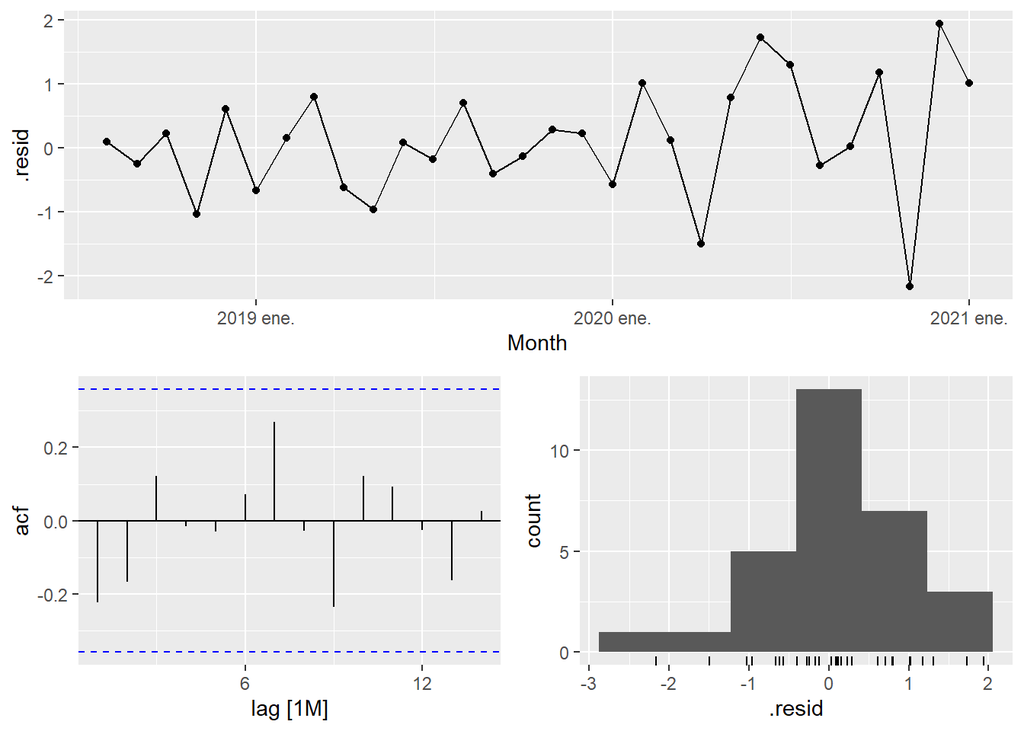

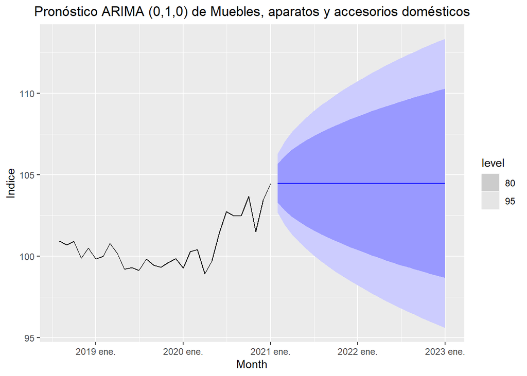

**OTROS SERVICIOS**

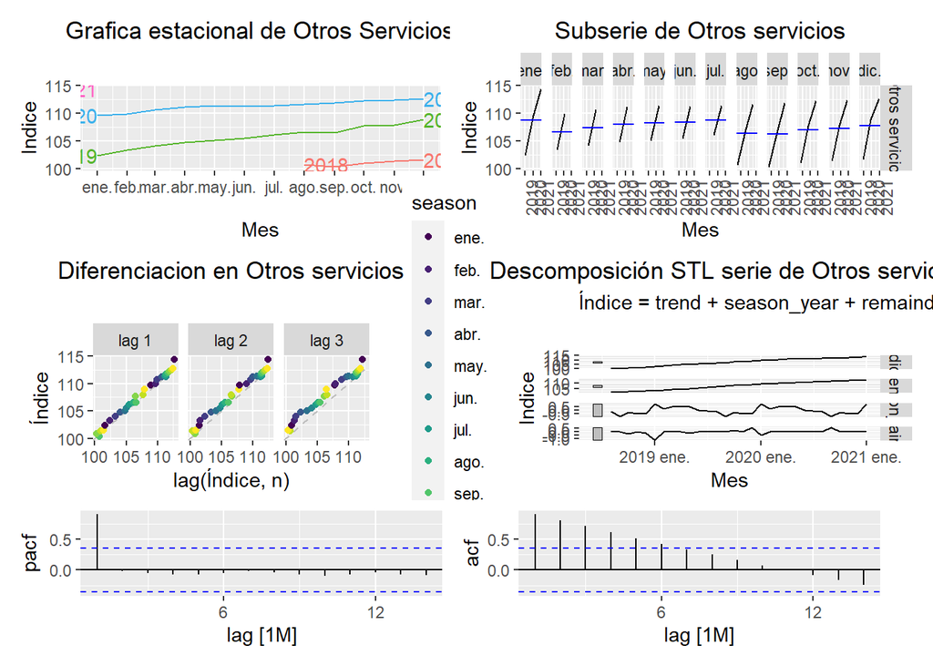

El pronostico para este Otros servicios es una Arima(0,1,0), asi como sus residuos despues del modelado,asi como un pronostico con el modelos propuesto.

```
## Series: Índice
## Model: ARIMA(0,1,0) w/ drift
##
## Coefficients:
##       constant
##         0.4711
## s.e.    0.0779
##
## sigma^2 estimated as 0.1827:  log likelihood=-15.96
## AIC=35.93   AICc=36.39   BIC=38.66
```

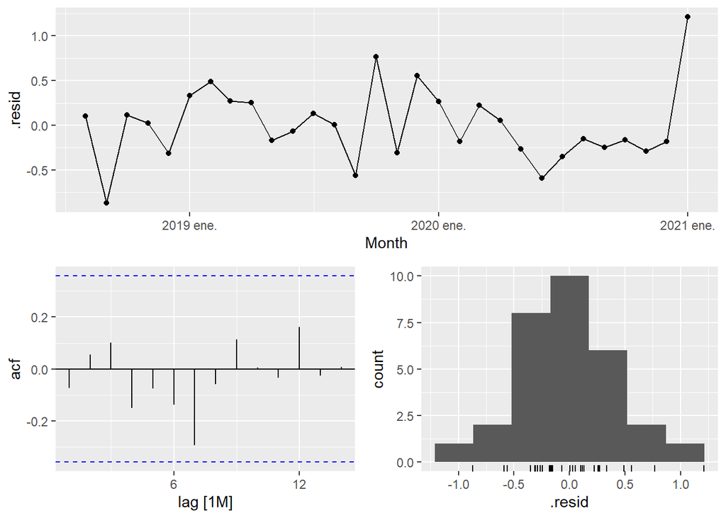

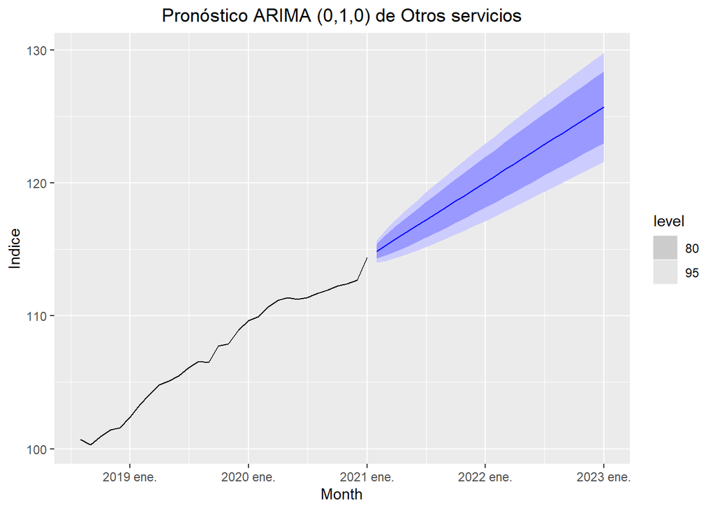

**ROPA, CALZADO Y ACCESORIOS**

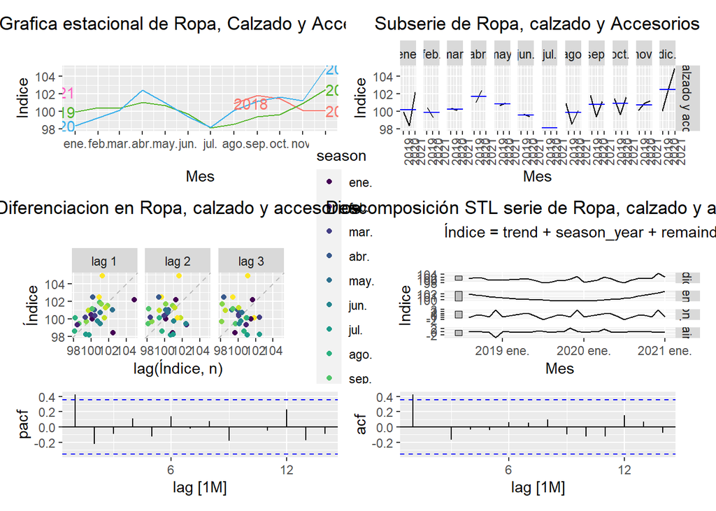

El pronostico para este Ropa, calzado y accesorios es una Arima(0,0,1), asi como sus residuos despues del modelado,asi como un pronostico con el modelos propuesto.

```
## Series: Índice
## Model: ARIMA(0,0,1) w/ mean
##
## Coefficients:
##          ma1  constant
##       0.4085  100.5331
## s.e.  0.1363    0.3275
##
## sigma^2 estimated as 1.77:  log likelihood=-50.19
## AIC=106.38   AICc=107.3   BIC=110.58
```

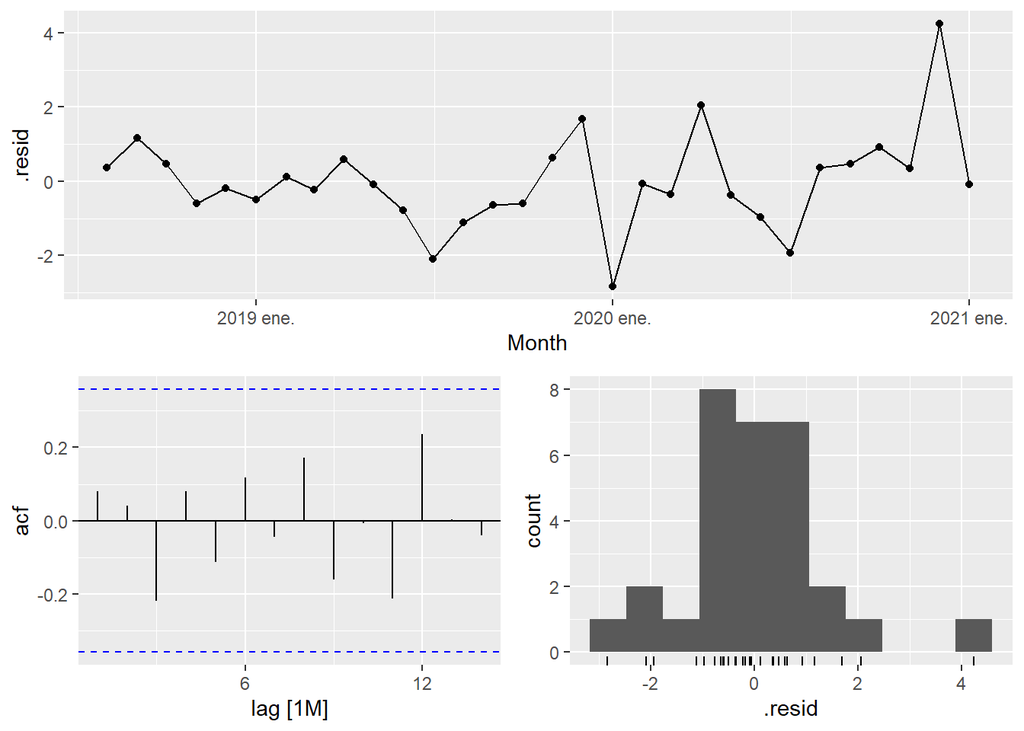

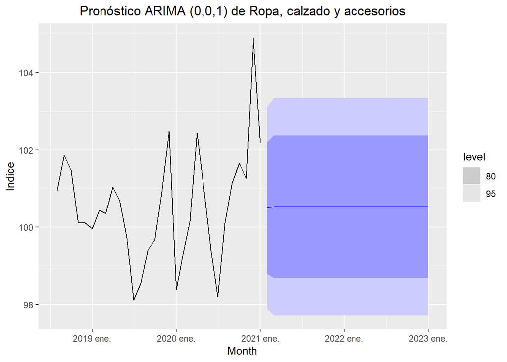

**SALUD Y CUIDADO PERSONAL**

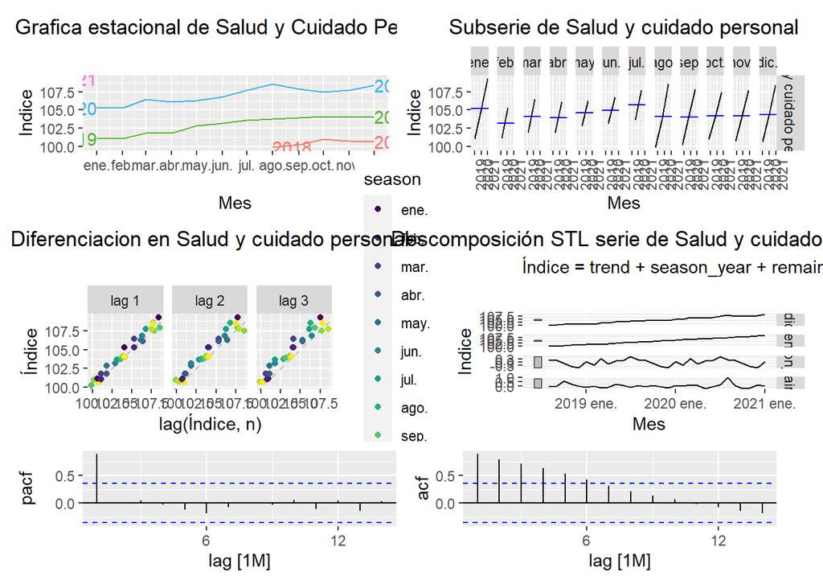

El pronostico para este Salud y Cuidado Personal es una Arima(4,1,0), asi como sus residuos despues del modelado,asi como un pronostico con el modelos propuesto.

```
## Series: Índice
## Model: ARIMA(4,1,0) w/ drift
##
## Coefficients:
##           ar1      ar2      ar3      ar4  constant
##       -0.3445  -0.1590  -0.5362  -0.4001    0.7672
## s.e.   0.1680   0.1586   0.1504   0.1722    0.0745
##
## sigma^2 estimated as 0.1715:  log likelihood=-13.55
## AIC=39.1   AICc=42.91   BIC=47.3
```

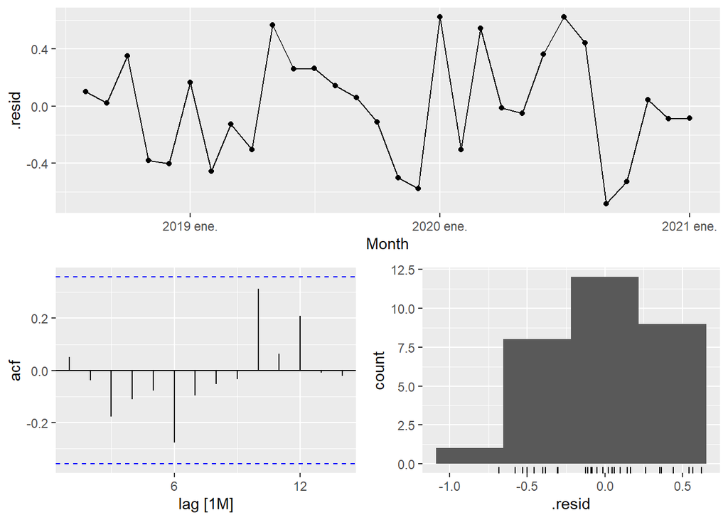

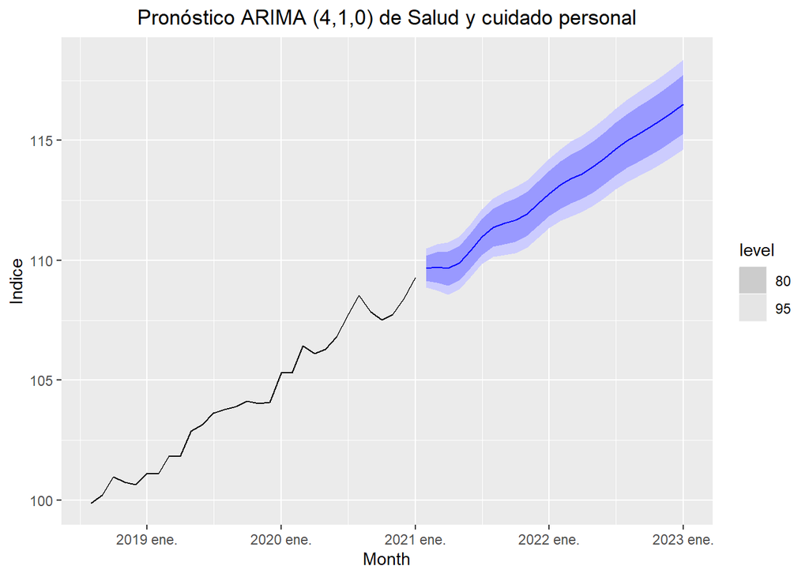

vemos en la siguiente tabla las diferentes correlaciones que hay entre los indices y los que mas se correlacionan, es decir que tienen un comportamiento mas parecido son el de Indice General con Alimentos y bebidas y los que tienen menos correlación son los de Salud y cuidado personal con Ropa, Calzado y Accesorios.

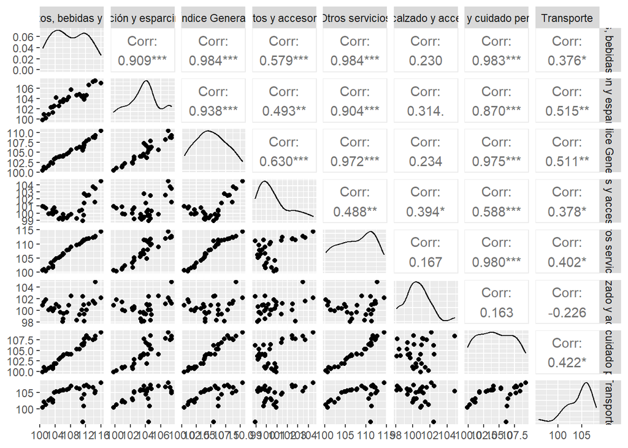

```r
INPCJ %>%
  pivot_wider(values_from=Índice, names_from=`Objeto de gasto`) %>%
  GGally::ggpairs(columns = 2:9)
```

lambda <- INPCJ %>% filter(`Objeto de gasto` == “Índice General”) %>% features(Índice, features = guerrero) %>% pull(lambda_guerrero)

INPCJ %>% filter(`Objeto de gasto` == “Índice General”) %>% autoplot(box_cox(Índice, lambda))

INPCJ %>% filter(`Objeto de gasto` == “Muebles, aparatos y accesorios domésticos”) %>% features(Índice, unitroot_ndiffs)

INPCJ %>% filter(`Objeto de gasto` == “Muebles, aparatos y accesorios domésticos”) %>% gg_tsdisplay(difference(diff_INPCJ), plot_type=‘partial’)

fit <- INPCJ %>% filter(`Objeto de gasto` == “Muebles, aparatos y accesorios domésticos”) %>% model( arima310 = ARIMA(diff_INPCJ ~ pdq(3,1,0) + PDQ(0,0,0)), arima011 = ARIMA(diff_INPCJ ~ pdq(0,1,1) + PDQ(0,0,0)) )

fit %>% select(arima011) %>% gg_tsresiduals() glance(fit)

fit %>% select(arima011) %>% augment() %>% features(.resid, ljung_box, lag = 24, dof = 4)

fit %>% select(arima011) %>% forecast() %>% autoplot()

fit4 <- INPCJ %>% filter(`Objeto de gasto` == “Muebles, aparatos y accesorios domésticos”) %>% model(ARIMA(diff_INPCJ ~ pdq(1:3, 0, 0:2) + PDQ(0,0,0))) report(fit4)

fit3 <- INPCJ%>% filter(`Objeto de gasto` == “Muebles, aparatos y accesorios domésticos”) %>% model(ARIMA(Índice ~ PDQ(0,0,0), stepwise = FALSE, approximation = FALSE)) report(fit3)

fit3 %>% gg_tsresiduals()

INPCJ%>% filter(`Objeto de gasto` == “Muebles, aparatos y accesorios domésticos”) %>% features(Índice,unitroot_kpss)

INPCJ%>% filter(`Objeto de gasto` == “Muebles, aparatos y accesorios domésticos”) %>% features(difference(difference(Índice)),unitroot_kpss)